# Quantifying Geographic Accessibility to Optimize Entomological Surveillance Site Selection in Kasaï-Central, DRC

A project proposal for MAP Early Career Researcher (ECR) study

Authors

Affiliations

Victoire Nsabatien

The Kids Research Institute Australia

Arsene Bokulu

Institut National de Recherche Biomédicale (INRB)

Kaiza Ilomo

Ifakara Health Institute

Published

July 15, 2026

Abstract

Malaria remains a major public health challenge in the Democratic Republic of Congo (DRC), where effective vector control relies on strong entomological surveillance systems. In DRC, sentinel surveillance sites are used to generate information on malaria vectors and support surveillance and vector-control decision-making. In Kasaï-Central Province, however, the provincial sentinel surveillance system currently relies on a single site located within one of the province’s 26 health zones. Given the province’s large geographic extent and environmental diversity, information generated from this site may not adequately represent conditions across the entire province. In addition, current site-selection does not consider seasonal accessibility and travel time, which may constrain the ability to sustain surveillance activities across seasons. This highlights the need for surveillance sites that are both operationally accessible and environmentally representative.This ECR project aims to evaluate the current sentinel surveillance network and identify priority locations for entomological surveillance in Kasaï-Central Province. Travel-time modelling and environmental suitability analysis will be used to assess accessibility and habitat suitability for malaria vectors across the province. The resulting information will be integrated to identify surveillance coverage gaps and prioritize existing and potential sentinel sites. Expected outputs include seasonal accessibility maps, an environmental suitability map, a surveillance coverage gap map, and a ranked list of priority surveillance locations. The findings of this project will support the evidence-based selection of sentinel sites that are both operationally accessible across seasons and environmentally representative of conditions across Kasaï-Central Province.

## 1 Background and rationale

Malaria remains a leading cause of morbidity and mortality in the Democratic Republic of Congo (DRC), where effective vector control relies on entomological surveillance. Sentinel surveillance sites provide critical information on malaria vectors and support evidence-based surveillance and vector-control decision-making. Under the initial national surveillance framework, each of the DRC’s 26 provinces was represented by a single sentinel site.

While this approach ensured national coverage, the ability of a single site to adequately represent large and environmentally diverse provinces remains uncertain. Effective sentinel surveillance depends on a network of sites that adequately represents geographic and environmental variation while remaining operationally accessible throughout the year. In Kasaï-Central Province, seasonal rainfall can affect road accessibility and travel times, potentially limiting routine surveillance activities. At the same time, the province’s environmental diversity raises questions about how well a single sentinel site can represent conditions across all 26 health zones. Consequently, the current surveillance network may not adequately capture the full geographic and environmental diversity of the province, potentially leaving important surveillance gaps. Evaluating accessibility, environmental representativeness, and geographic coverage is therefore essential for identifying priority locations for entomological surveillance.

Recent efforts by the National Malaria Control Programme (NMCP) to strengthen the sentinel surveillance system have focused primarily on programmatic and operational indicators. While these indicators are important, they may not fully address the spatial and environmental dimensions of surveillance-site selection. In particular, seasonal accessibility, environmental representativeness and geographic coverage are not systematically considered. Consequently, the current surveillance network may not adequately capture the full range of geographic and environmental conditions across provinces such as Kasaï-Central, potentially resulting in surveillance coverage gaps.

Addressing this knowledge gap could provide valuable evidence for strengthening surveillance planning and guiding future sentinel site selection. Advances in geographic information systems (GIS), remote sensing, and travel-time modelling provide an opportunity to systematically evaluate accessibility, environmental representativeness, and surveillance coverage.

This project therefore proposes to evaluate the current sentinel surveillance network and identify priority locations for entomological surveillance in Kasaï-Central Province. The findings will support evidence-based sentinel site selection and contribute to strengthening malaria vector surveillance across the province.

## 2 Study setting

This study will be conducted in the Kasaï-Central province, one of 10 most malaria affected provinces (out of 26 provinces) in the Democratic Republic of the Congo (DRC) that collectively account for 64% of the national malaria burden (Figure 1).

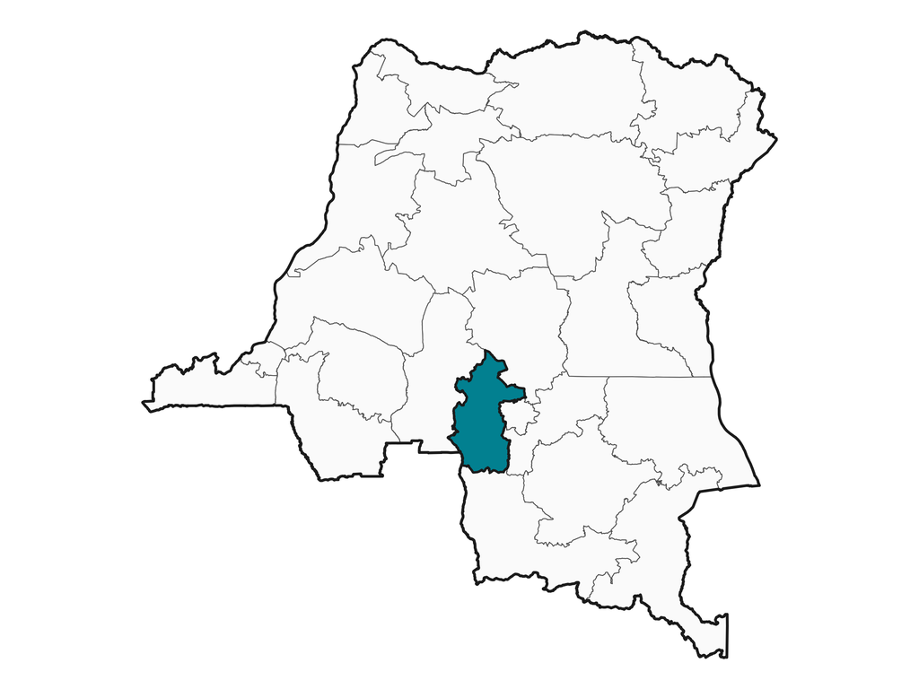

Figure 1: Location of Kasaï-Central Province (highlighted in teal) among the 26 provinces of the Democratic Republic of Congo.

The province covers approximately **60,000 km²** and is organised into **26 health zones**, **466 health areas**, and **4,856 villages** within the health system.(Figure 2). Despite its large geographic extent and environmental heterogeneity, entomological surveillance currently relies on a single sentinel site located in Mikalayi health zone.

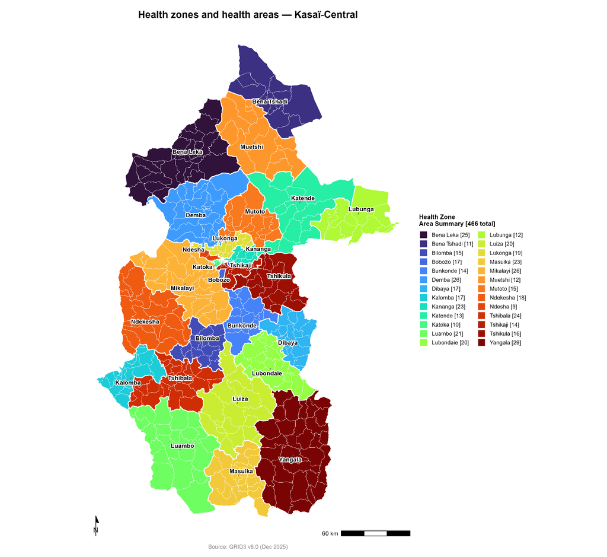

Figure 2: Health zones and their constituent health areas across Kasaï-Central (466 areas total). Source: GRID3 v8.0.

Health areas and villages per health zone, Kasaï-Central province.

| Health zones | Health areas | Villages |
| --- | --- | --- |
| Bena Leka | 25 | 267 |
| Bena Tshiadi | 11 | 120 |
| Bilomba | 15 | 224 |
| Bobozo | 17 | 40 |
| Bukonde | 14 | 136 |
| Demba | 26 | 296 |
| Dibaya | 17 | 169 |
| Kalomba | 17 | 248 |
| Kananga | 23 | 173 |
| Katende | 13 | 89 |
| Katoka | 10 | 69 |
| Luambo | 21 | 305 |
| Lubondaie | 20 | 95 |
| Lubunga | 12 | 142 |
| Luiza | 20 | 251 |
| Lukonga | 19 | 127 |
| Masuika | 23 | 239 |
| Mikalayi | 26 | 349 |
| Muetshi | 12 | 142 |
| Mutoto | 15 | 155 |
| Ndekesha | 18 | 194 |
| Ndesha | 9 | 110 |
| Tshibala | 24 | 306 |
| Tshikaji | 14 | 185 |
| Tshikula | 16 | 192 |
| Yangala | 29 | 233 |
| **Total** | **466** | **4,856** |

## 3 Aim and research questions

To evaluate the current entomological sentinel surveillance network and identify an accessible and environmentally representative set of priority surveillance locations in Kasaï-Central Province under different seasonal conditions.

## 4 Research Questions

### 4.1 Research Question 1

How does seasonal variation affect travel-time accessibility to current and potential entomological sentinel surveillance locations in Kasaï-Central Province?

### 4.2 Research Question 2

Which locations should be prioritised for future entomological surveillance when seasonal accessibility, environmental representativeness, and geographic coverage are considered together?

## 5 Objectives

1. To assess seasonal accessibility to current and potential entomological surveillance locations by estimating travel times under different seasonal conditions.
2. To evaluate the environmental representativeness and geographic coverage of the current sentinel surveillance network.
3. To identify surveillance gaps by assessing the combined effects of accessibility, environmental representativeness, and geographic coverage.
4. To prioritise potential sentinel surveillance locations by integrating seasonal accessibility, environmental representativeness, and geographic coverage.

## 6 Conceptual Framework

Effective entomological surveillance requires sentinel sites that are both operationally accessible and representative of the geographic and environmental diversity of the areas under surveillance. To address this requirement, the proposed framework integrates three complementary dimensions of surveillance performance: seasonal accessibility, environmental representativeness, and geographic coverage.

Seasonal accessibility will be evaluated through travel-time modelling to determine the extent to which surveillance locations can be reached under different seasonal conditions. Environmental representativeness will be assessed to determine whether the current surveillance network adequately captures the environmental diversity of Kasaï-Central Province. Geographic coverage will be examined to identify areas that are poorly represented or insufficiently covered by the existing surveillance network.

The outputs from these analyses will be integrated to identify surveillance coverage gaps and prioritise potential sentinel surveillance locations. The resulting framework will support evidence-based decision-making for sentinel site selection and future network expansion in Kasaï-Central Province.

## 7 Methodology

### 7.1 Study Design

This study will use a spatial analytical approach to evaluate the current entomological sentinel surveillance network and identify priority surveillance locations in Kasaï-Central Province. The study will be conducted through four interconnected work packages (WPs).

### 7.2 Data source

This study will integrate health-system, entomological, geographic, environmental, and climatic datasets to evaluate the current entomological sentinel surveillance network and identify priority locations for future sentinel surveillance in Kasaï-Central Province.

- **Health-system data**: Geographic coordinates of the existing sentinel site in Mikalayi Health Zone, health-facility locations, health-zone boundaries, health-area boundaries, and village locations obtained from the GRID3 DRC geospatial database. These datasets will be used to evaluate the current surveillance network, identify potential sentinel locations, and support spatial analyses.
- **Entomological data**: Open-access malaria vector occurrence records obtained from the Vector Atlas. These data will be used to characterise malaria vector distribution and support environmental suitability and representativeness analyses.
- **Road network data**: OpenStreetMap road network data used to estimate travel times and assess seasonal accessibility to existing and potential surveillance locations.
- **Environmental covariates**: Environmental datasets including elevation, surface water, rainfall, land cover, and vegetation indices (e.g., NDVI,) obtained from publicly available remote-sensing products. These variables will be used to characterize environmental conditions across Kasaï-Central Province, assess environmental representativeness, support environmental suitability analyses, and contribute to seasonal accessibility modelling.

## 8 Working packages

### 8.1 WP1. Seasonal Accessibility Assessment

#### 8.1.1 Rationale

Accessibility is a key determinant of the operational feasibility of entomological surveillance. Seasonal rainfall can affect road conditions and travel times, potentially limiting access to surveillance locations during parts of the year.

### 8.2 Methods

Travel-time surfaces will be generated to quantify accessibility across Kasaï-Central Province under different seasonal conditions. These surfaces will be used to assess the accessibility of existing and potential sentinel surveillance locations and to identify areas where seasonal conditions may constrain surveillance activities.

### 8.3 Main Outputs

- **Seasonal accessibility maps** describing travel times to existing and potential surveillance locations across Kasaï-Central Province under different seasonal conditions.

### 8.4 WP2. Environmental Representativeness Assessment

#### 8.4.1 Rationale

A sentinel surveillance network should adequately represent the environmental diversity of the province to ensure that entomological observations reflect the range of conditions influencing malaria vector distribution. Assessing environmental representativeness is therefore essential for determining whether the current surveillance network captures the environmental settings relevant to malaria vectors across Kasaï-Central Province.

### 8.5 Methods

Environmental suitability modelling will be used to characterise conditions associated with malaria vector occurrence across Kasaï-Central Province. Vector occurrence records obtained from the Vector Atlas will be combined with environmental covariates, including rainfall, land cover, vegetation indices, elevation, and surface water, to generate a province-wide environmental suitability surface. The resulting map will be used to assess how well the environmental conditions represented by the current sentinel site reflect the broader environmental diversity of the province.

### 8.6 Main Outputs

- **Environmental suitability map** identifying areas with environmental conditions favourable for malaria vectors across Kasaï-Central Province.

### 8.7 WP3. Surveillance Gap Analysis

#### 8.7.1 Rationale

Surveillance gaps may occur when areas of environmental importance are not represented within the current surveillance network or when seasonally inaccessible locations limit surveillance activities. Identifying these gaps is necessary for improving the representativeness and coverage of entomological surveillance across the province.

### 8.8 Methods

Outputs from the seasonal accessibility assessment (WP1) and environmental representativeness assessment (WP2) will be integrated to identify areas that are poorly represented by the current surveillance network. Particular attention will be given to locations that combine high environmental suitability with limited accessibility or lack of surveillance coverage.

### 8.9 Main Outputs

- **Surveillance coverage gap map** identifying priority areas that are currently underrepresented by the sentinel surveillance network.

### 8.10 WP4. Sentinel Site Prioritisation

#### 8.10.1 Rationale

Improving surveillance coverage requires the identification of locations that are both operationally accessible and environmentally representative. Integrating these considerations can support evidence-based selection of future sentinel sites.

### 8.11 Methods

Accessibility, environmental representativeness, and surveillance coverage information generated in WP1–WP3 will be combined within a spatial prioritisation framework. Candidate locations will be evaluated according to their potential contribution to improving surveillance coverage while remaining operationally accessible across seasons.

### 8.12 Main Outputs

- **Ranked list of priority surveillance locations** for future entomological surveillance in Kasaï-Central Province.

## 9 Expected Impact

The project will provide evidence to support the selection of sentinel surveillance sites that are both operationally accessible across seasons and environmentally representative of conditions across Kasaï-Central Province. The findings are expected to: - Improve understanding of seasonal accessibility constraints affecting entomological surveillance activities; - Identify geographic and environmental areas that are underrepresented by the current surveillance network; - Support evidence-based prioritisation of future sentinel surveillance locations; and - Strengthen malaria vector surveillance and vector-control planning in Kasaï-Central Province.

## 10 Next steps

Immediate next steps are to (1) confirm scope and lead research question with mentors, (2) Compile and harmonise the health-system, entomological, geographic, environmental, and climatic datasets required for the study, and (3) develop an initial travel-time surface for a selected health zone, with support from Christine, as a proof of concept for the accessibility modelling framework.

## 11 Key reference

Weiss *et al.* and related accessibility work motivate the core method; the directly relevant methodological reference is *Quantifying geographic accessibility to improve efficiency of entomological monitoring* ([bioRxiv 10.1101/779561v2](https://www.biorxiv.org/content/10.1101/779561v2.full)).

Longbottom *et al.* (2020) Quantifying geographic accessibility to improve efficiency of entomological monitoring. PLOS Neglected Tropical Diseases 14(3): e0008096. https://doi.org/10.1371/journal.pntd.0008096